# Data Consulting Report

Author

Hans Capener

### ABSTRACT

**RESULTS**

## LOGISTIC REGRESSION

**Happy Rating and Logistic Regression**

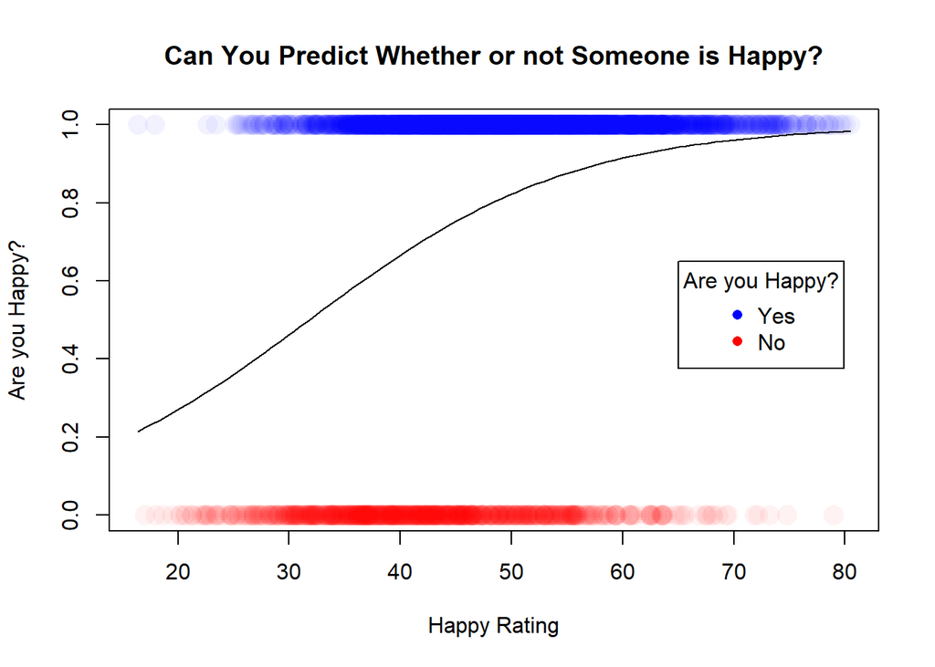

```r
library(haven)
library(mosaic)
library(plotly)
library(htmltools)
library(tidyverse)
library(pander)
gss2021 <- read_sas("data/gss2021.sas7bdat",
    NULL)

# Filter Data and Create Happy_Rating
mygss <- gss2021 %>%
  select(c('HAPPY', 'HAPMAR','LIFE', 'SATSOC', 'HLTHMNTL', 'ACTSSOC', 'HEALTH', 'EMOPROBS', 'ATTEND', 'EDUC', 'RELACTIV', 'HLTHPHYS')) %>%
  filter(!is.na(HAPPY)) %>% # Drop NA rows in the "HAPPY" column
  mutate( # Merge "Pretty Happy" and "Very Happy" columns to just be "Happy" ~ 1
    HAPPY = case_when(
      HAPPY %in% c(1,2) ~ 1,
      HAPPY %in% 3 ~ 0
    )
  ) %>%
  mutate_all(~ifelse(is.na(.), mean(., na.rm = TRUE), .)) %>% # Fill NA with mean()
  mutate_all(~ . / max(.)) %>%  # Divide each column by its max value
  mutate( # Invert scale on questions that had inverse numbered answers
    ATTEND = ATTEND * -1 + 1,
    RELACTIV = RELACTIV * -1 + 1,
    EDUC = EDUC * -1 + 1,
  ) %>%
  mutate( # Scale each factor to match its importance in the ML
    Happy_Rating = -100 * (EDUC * 0.15426218 +
                   ATTEND * 0.12488643 +
                   HAPMAR * 0.11542531 +
                   RELACTIV * 0.11377695 +
                   SATSOC * 0.08842675 +
                   EMOPROBS * 0.08201357 +
                   LIFE * 0.07298428 +
                   ACTSSOC * 0.06718067 +
                   HLTHMNTL * 0.06597608 +
                   HLTHPHYS * 0.06001798 +
                   HEALTH * 0.05504979) + 100,
    Happy_Rating_Unscaled = -10 * (EDUC +
                   ATTEND + HAPMAR +
                   RELACTIV + SATSOC +
                   EMOPROBS + LIFE +
                   ACTSSOC + HLTHMNTL +
                   HLTHPHYS + HEALTH) + 100
  )

# Run Logistic Regression
gss.glm <- glm(HAPPY ~ Happy_Rating, data = mygss, family=binomial)

# Graph Logistic Regression
palette(c(rgb(1,0,0, alpha =0.05),rgb(0,0,1, alpha =0.05)))
plot(HAPPY ~ Happy_Rating, data = mygss, col=as.factor(HAPPY), pch=16, cex=2, xlab = "Happy Rating", ylab = "Are you Happy?", main = "Can You Predict Whether or not Someone is Happy?")
b <- coef(gss.glm)
curve(exp(b[1] +b[2]*x)/(1+exp(b[1] +b[2]*x)), add=TRUE)
legend(x=65, y=0.65, legend = c("Yes", "No"), col = c('blue', 'red'), pch = 16, title = "Are you Happy?")
```

There is a significant relationship between this custom happiness rating and whether or not someone is happy.

## HAPPY RATING FACTORS

Rated top down by importance as found by machine learning model (Note: one or two of these features may shift in importance depending on the specific iteration of the RandomForestClassifier Model)

1. Years of Education
2. Attendance of Religious Services
3. Happiness of Marriage
4. Attendance of Religious Activities
5. Satisfaction in social activities and relationships
6. Frequency of Emotional Problems
7. How exciting or dull life is
8. Ability to carry out social activities
9. Mental Health
10. Physical Health
11. General Health

```python
# Import Libraries
import pandas as pd
import altair as alt
import numpy as np
from sklearn.ensemble import RandomForestClassifier
from sklearn.model_selection import train_test_split
from sklearn import metrics

# Import SAS Dataset
dat = pd.read_sas('data\gss2021.sas7bdat')

# Drop NaN Values in HAPPY column
dat.dropna(subset=['HAPPY'], inplace=True)

# Drop all columns that are all NA values
dat.dropna(axis=1, how='all', inplace=True)

# Filter dataset to just needed columns
new_dat = dat.filter(['HAPPY', 'HAPMAR', 'LIFE', 'SATSOC', 'HLTHMNTL', 'ACTSSOC', 'HEALTH', 'EMOPROBS', 'ATTEND', 'EDUC', 'RELACTIV', 'HLTHPHYS'], axis=1)

# Fill the remaining NaN values with the mean of each of the columns
new_dat.fillna(new_dat.mean(), inplace=True)

# Convert HAPPY to two categories, Happy and Unhappy
def happy_filter(df):
    if df >= 2:
        return 1
    if df == 1:
        return 0
fix_happy = new_dat.HAPPY.astype(int).apply(happy_filter)

# Split data into train and test groups
x = new_dat.drop('HAPPY', axis=1)
y = fix_happy
x_train, x_test, y_train, y_test = train_test_split(x, y, test_size= .2, random_state= 1234)

# Fit RandomForestClassifier
clf_rf = RandomForestClassifier().fit(x_train, y_train)

# Graph feature importances
feature_df = pd.DataFrame({'features':x.columns, 'importance':clf_rf.feature_importances_})

chart = alt.Chart(feature_df).encode(
    x = alt.X('importance'),
    y = alt.Y('features', sort='-x')
).mark_bar()
chart
```

[output not shown]

Training the Random Forest Classifier with the selected factors trains a model with the following accuracy:

**Model Accuracy**

```python
y_pred_rf = clf_rf.predict(x_test)
accuracy_rf = metrics.accuracy_score(y_pred_rf, y_test)
print(f"RandomForest: {accuracy_rf}")
```

```
RandomForest: 0.8356164383561644
```

Both our machine learning model and logistic regression show a clear trend with these factors.

## CONCLUSIONS

It is very interesting, that of all these traits, Physical, Mental, and general Health are the least predictive in one’s happiness; more important than all of those is Education, Religion, and the relationships we have with others. Taking a step back, we can conclude that one’s health, relationships, education, religion, and social activites are key indicators for one’s happiness.

**LOGISTIC REGRESSION**

## Hypothesis

Using a Logistic Regression, we can determine if this custom Happiness Rating is a significant factor of one’s happiness. If rating is a significant factor, it can be used in the future to predict one’s happiness without needing to ask the question. We will have a significance level of $\alpha = 0.05$ and use the following model:

$$\underbrace{P(Y_i = 1|\, x_i)}_\text{Probability person is happy} = \frac{e^{\beta_0 + \beta_1 x_i}}{1+e^{\beta_0 + \beta_1 x_i}} = \pi_i$$

Our hypothesis are related to the $\beta_1$ term, which tells us if there is a relationship between the rating and happiness. $\beta_0$ doesn’t provide much insight in this context, because knowing the happiness of a person with zero happy rating isn’t needed for our objective.

$H_0: \beta_1 = 0$

$H_a: \beta_1 \neq 0$

Performing the Logistic Regression gives us the following results:

## Logistic Regression Summary

**Graph**

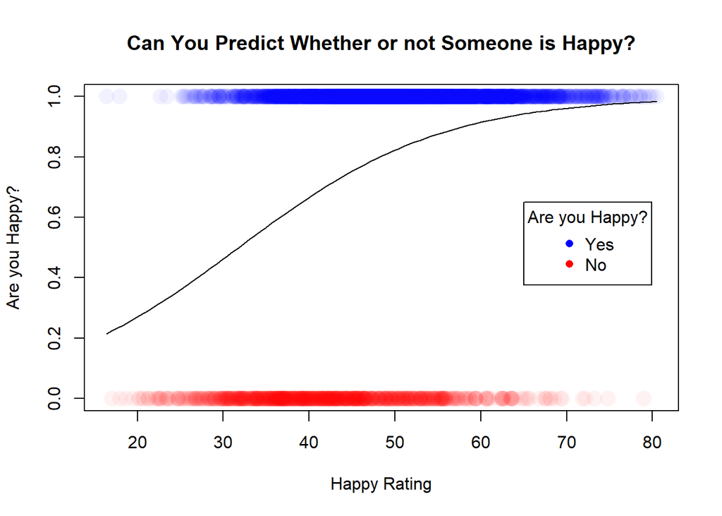

```r
palette(c(rgb(1,0,0, alpha =0.05),rgb(0,0,1, alpha =0.05)))
plot(HAPPY ~ Happy_Rating, data = mygss, col=as.factor(HAPPY), pch=16, cex=2, xlab = "Happy Rating", ylab = "Are you Happy?", main = "Can You Predict Whether or not Someone is Happy?")
b <- coef(gss.glm)
curve(exp(b[1] +b[2]*x)/(1+exp(b[1] +b[2]*x)), add=TRUE)
legend(x=65, y=0.65, legend = c("Yes", "No"), col = c('blue', 'red'), pch = 16, title = "Are you Happy?")
```

**Regression Summary**

```r
summary(gss.glm) %>%
    pander(caption="Logistic Regression Summary")
```

|  | Estimate | Std. Error | z value | Pr(>\|z\|) |
| --- | --- | --- | --- | --- |
| **(Intercept)** | -2.679 | 0.1977 | -13.55 | 7.843e-42 |
| **Happy_Rating** | 0.08426 | 0.004378 | 19.25 | 1.498e-82 |

(Dispersion parameter for binomial family taken to be 1 )

| Null deviance: | 4329 on 4013 degrees of freedom |
| --- | --- |
| Residual deviance: | 3876 on 4012 degrees of freedom |

Looking at our p-values, there is sufficient evidence to reject our null hypothesis. There is a significant relationship between our custom Happy Rating and one’s happiness.

## Goodness of Fit test

Due to there being 111 repeated values in our Happy Rating data, we will use the Deviance Goodness-of-fit Test to determine if this model is a good fit for our data:

**Deviance Goodness-of-fit Test**

```r
pchisq(3876.3, 4012, lower.tail=FALSE) %>%
    pander(caption="P-value for Deviance Goodness-of-fit Test")
```

*0.9364*

With a p-value of 0.9364, we can conclude that this model is a good fit for our data.

**RATING DERIVATION**

## Survey Questions

Each of the following Questions have the following answer options:

- 1 - Excellent
- 2 - Very Good
- 3 - Good
- 4 - Fair
- 5 - Poor

SATSOC - In general, how would you rate your satisfaction with your social activities and relationships?

HLTHMNTL - In general, how would you rate your mental health, including your mood and your ability to think?

ACTSSOC - In general, please rate how well you carry out your usual social activities and roles. (This includes activities at home, at work and in your community, and responsibilities as a parent, child, spouse, employee, friend, etc.)

HLTHPHYS - In general, how would you rate your physical health?

HEALTH: 1 - 4 (no very good) - Would you say your own health, in general, is excellent, good, fair, or poor?

EMOPROBS - In the past seven days, how often have you been bothered by emotional problems such as feeling anxious, depressed or irritable?

- 1 - Never
- 2 - Rarely
- 3 - Sometimes
- 4 - Often
- 5 - Always

LIFE - In general, do you find life exciting, pretty routine, or dull?

1 - Exciting 2 - Routine 3 - Dull

ATTEND - How often do you attend religious services?

- 0 - Never
- 1 - Less than once a year
- 2 - About once or twice a year
- 3 - Several times a year
- 4 - About once a month
- 5 - 2-3 times a month
- 6 - Nearly every week
- 7 - Every week
- 8 - Several times a week

RELACTIV - How often do you take part in the activities and organizations of a church or place of worship other than attending services?

- 1 - Never
- 2 - Less than once a year
- 3 - About once or twice a year
- 4 - Several times a year
- 5 - About once a month
- 6 - 2-3 times a month
- 7 - Nearly every week
- 8 - Every week
- 9 - Several times a week
- 10 - Once a day
- 11 - Several times a day

EDUC - Highest year of education?

- 0 - 20 Years

HAPMAR - Would you say that your marriage is very happy, pretty happy, or not too happy?

- 1 - Very Happy
- 2 - Pretty Happy
- 3 - Not too Happy

## Turning Questions into Happy Rating

```r
# SELECT COLUMNS
mygss <- gss2021 %>%
  select(c('HAPPY', 'HAPMAR','LIFE', 'SATSOC', 'HLTHMNTL', 'ACTSSOC', 'HEALTH', 'EMOPROBS', 'ATTEND', 'EDUC', 'RELACTIV', 'HLTHPHYS')) %>%
# Drop NA rows in the "HAPPY" column
  filter(!is.na(HAPPY)) %>%
# Merge "Pretty Happy" and "Very Happy" columns to just be "Happy" ~ 1
  mutate(
    HAPPY = case_when(
      HAPPY %in% c(1,2) ~ 1,
      HAPPY %in% 3 ~ 0
    )) %>%
# Fill NA with mean()
  mutate_all(~ifelse(is.na(.), mean(., na.rm = TRUE), .)) %>%
# Divide each column by its max value
  mutate_all(~ . / max(.)) %>%
# Invert scale on questions that had inverse numbered answers
  mutate(
    ATTEND = ATTEND * -1 + 1,
    RELACTIV = RELACTIV * -1 + 1,
    EDUC = EDUC * -1 + 1,
  ) %>%
# Scale each factor to match its importance in the ML
  mutate(
    Happy_Rating = -100 * (EDUC * 0.15426218 +
                   ATTEND * 0.12488643 +
                   HAPMAR * 0.11542531 +
                   RELACTIV * 0.11377695 +
                   SATSOC * 0.08842675 +
                   EMOPROBS * 0.08201357 +
                   LIFE * 0.07298428 +
                   ACTSSOC * 0.06718067 +
                   HLTHMNTL * 0.06597608 +
                   HLTHPHYS * 0.06001798 +
                   HEALTH * 0.05504979) + 100,
    Happy_Rating_Unscaled = -10 * (EDUC +
                   ATTEND + HAPMAR +
                   RELACTIV + SATSOC +
                   EMOPROBS + LIFE +
                   ACTSSOC + HLTHMNTL +
                   HLTHPHYS + HEALTH) + 100
  )
```